# Causal Inference for Observational Longitudinal Survival Data

Mark Bech Knudsen

## Context

Thesis written in blocks 1 & 2 autumn 2022, supervised by Torben Martinussen & Helene Rytgaard @ Biostatistics KU.

Thesis explores 3 topics relating to causal inference for non-randomized survival data:

- Can we interpret hazard ratios causally?
- A problem with Markov models for survival data.
- Continuous-time inverse probability weighting.

## Defining causal effects

Assume a binary treatment $A \in \{0, 1\}$ that is given at time $t = 0$. Wish to infer the *effect of treatment on survival*.

The effect of treatment could then be defined as
$$P(T^1 > t) - P(T^0 > t)$$
i.e. how much more likely is it for the person to survive if they receive treatment vs. if they do not?

Or on the population scale: What would the survival rate be if we treated everyone vs. if we did not treat anyone?

Different from the conditional association $P(T > t \mid A = 1) - P(T > t \mid A = 0)$.

## Causal vs. conditional effects

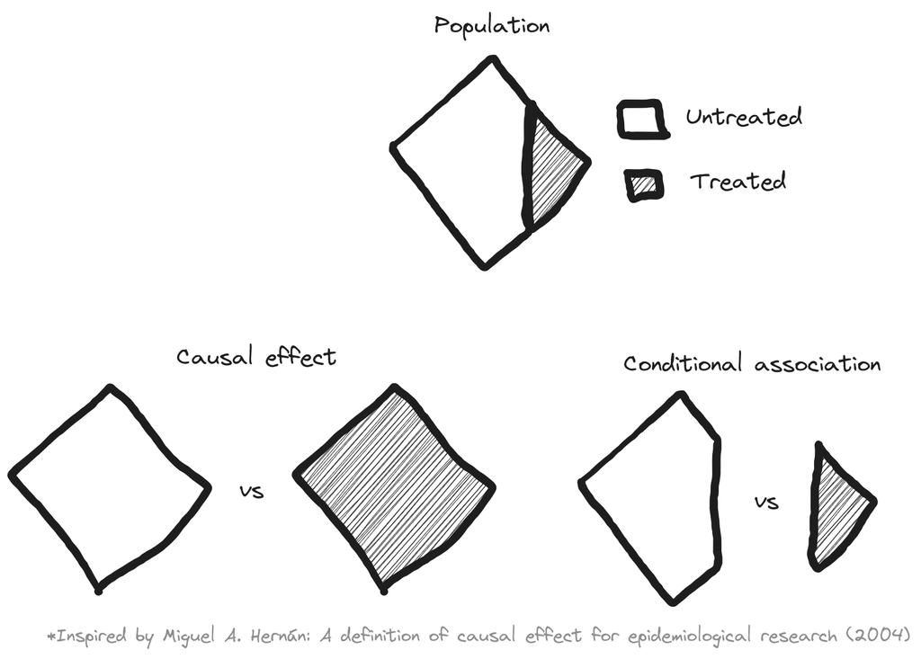

## Randomized treatment

Assume a randomized treatment $A$. Then the subpopulation with $A = a$ is *representative* of what would have happened to the rest of the population, *had they been treated*.

Scale up subpopulation to full population size with weights
$$W_i^a = \frac{1(A_i = a)}{P(A = a)}$$

An estimate of the probability of survival, had everyone received treatment $a$:
$$P(T^a > t) = \frac{1}{n} \sum_{i=1}^n W_i^a 1(T_i > t)$$

The $W_i^a$ are referred to as *inverse probability of treatment weights (IPTW)*.

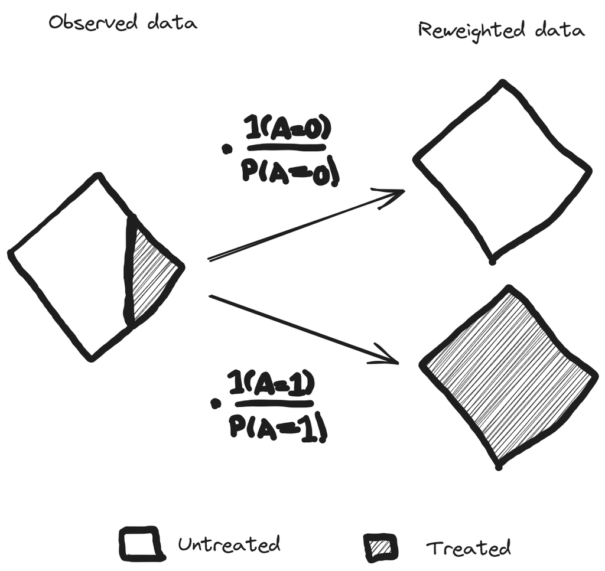